# Team Name: BIG APPLE

Members: Felix Su, Peter Wang, Bolun Deng, William Liu, Steven Ma

# Project Overview and Questions

**Overview**: Analysis of Apple’s Stock Reactions to Product Releases, Important Events, and Competition

**Questions:**

1.How does percent of revenue by product of the Apple company change throughout the course of history of Apple?

2.How does Apple’s stock price perform when compared against product releases and important events in its history?

**Data Sets**

1. Apple Stock/Product Releases: Yahoo Finance and Timetoast.com
2. Apple % Revenue by Product: Bare Figures
3. Apple vs. Microsoft Stocks: Yahoo Finance
4. Apple Asset Breakdown: Apple Inc. Balance Sheet Quarterly Report

> Note: Although the graphs seem to be simple, the process of obtaining and cleaning the data is complicated and prolonged because it involves web scraping.

**Apple Stock and Product Correlation**

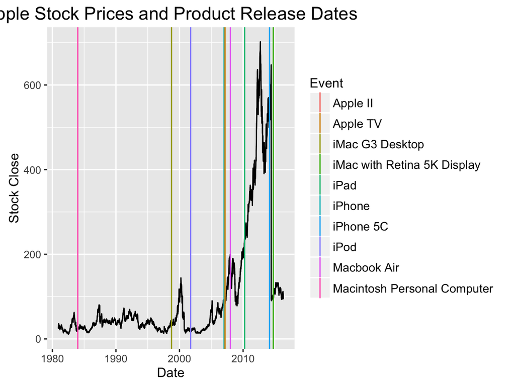

**Percent of Revenue by product of Apple Inc.**

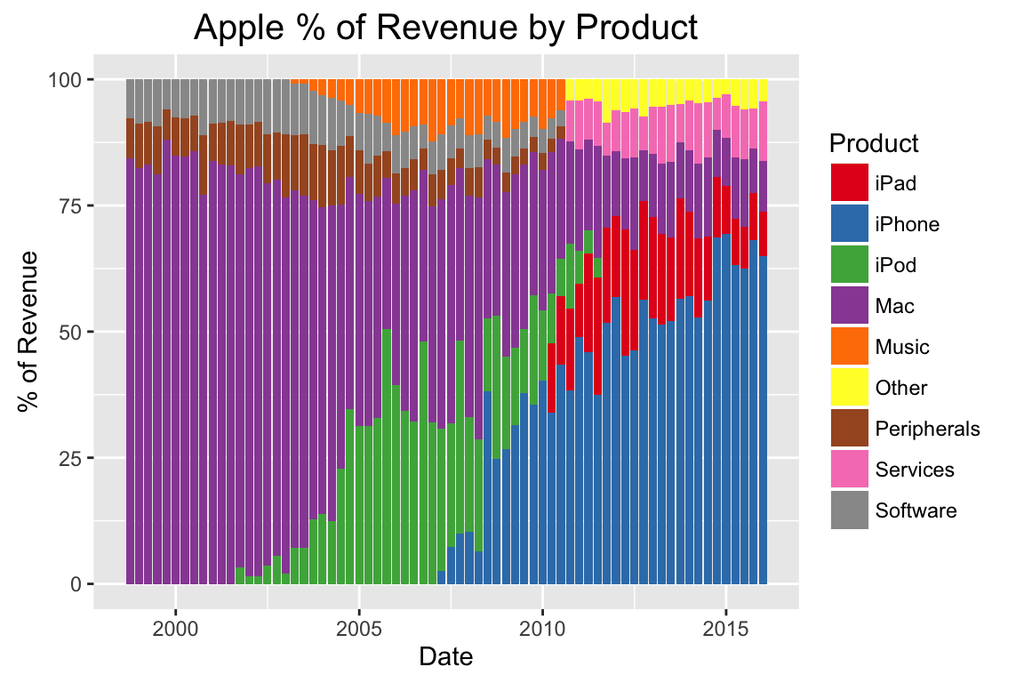

**Apple vs. Microsoft Stock Comparison**

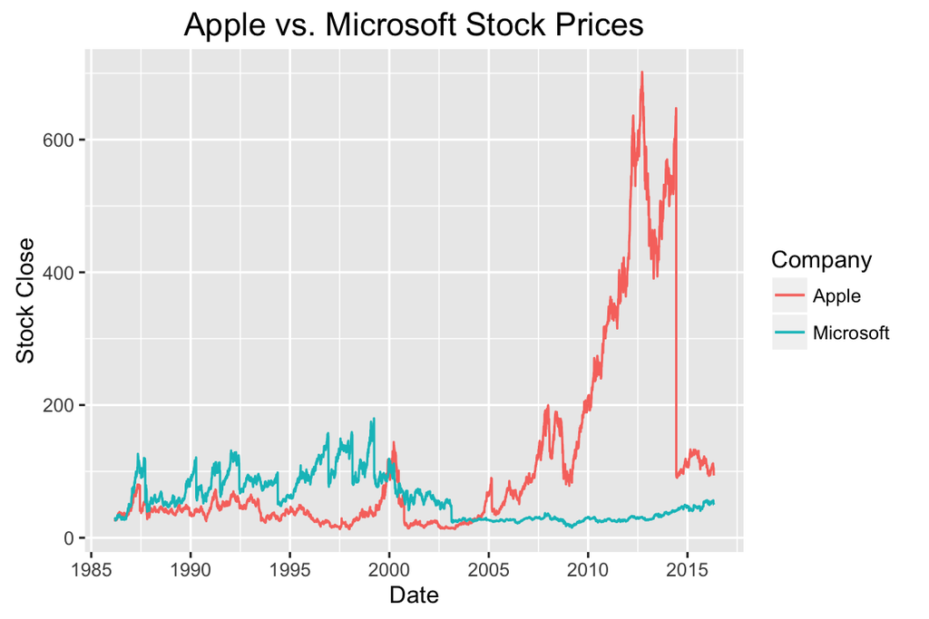

**Plot of Apple’s Assets**

- The variables of interest are the values of Apple’s Total Assets, Equipment/Property, and Liabilities from 2004-2016.
- 2010+ spikes in Assets and Liabilities shows continued growth while Equipment/Property assets stay low and avoid depreciation costs.

[figure not shown]